# Composable Preprocessing Operators: `mlrCPO`

When applying a machine learning algorithm (i.e. a `Learner` in `mlr`) to a dataset, it is often beneficial to do certain operations to the data (e.g. removal of constant columns, principal component analysis) in a step called “*preprocessing*”. `mlr` already provides some basic preprocessing functionality, but it is limited in scope and quite inflexible. A much better toolset is now provided by [**mlrCPO**](https://github.com/mlr-org/mlrCPO#project-status).

The central objects provided by mlrCPO are “composable preprocessing operators”, called **CPO**s. They make it possible to handle a preprocessing operation as an R object, to combine multiple operations (sequentially, or in parallel) to form new ones, and to attach preprocessing objects to `Learner` objects to form complete machine learning pipelines. Just like a `Learner`, a `CPO` can have hyperparameters, which can also be tuned using `mlr`’s tuning functionality.

## Example Application: The Kaggle “Titanic” Dataset

The possibilities offered by `mlrCPO` can best be demonstrated using example. The following is just giving an overview and not an in-depth tutorial; to go deeper into `mlrCPO`, consult the package’s vignettes.

```r
library("mlrCPO")
```

A dataset that can make good use of preprocessing operations is [the “Titanic” dataset on Kaggle](https://www.kaggle.com/c/titanic/data). We can use feature engineering on some of the more awkward character string features, and for some features we need to do missing value imputation. One issue with the dataset is that the baseline performance using just the “Sex” and “Pclass” columns is already quite high, which makes improvements of algorithm performance that result from preprocessing hard to measure. For demonstration purposes we are therefore going to simulate a “harder” dataset by removing the “Sex” and “Pclass” columns. If the `train.csv` file from Kaggle is in the working directory, it should be loaded into an `mlr`-compatible `Task` using

```r
titanic.table = read.csv("train.csv", na.str = "")
titanic.table$Pclass = NULL
titanic.table$Sex = NULL

titanic.task = makeClassifTask("titanic", titanic.table,
  target = "Survived", positive = 1)

test.table = read.csv("test.csv", na.str = "")
test.table$Pclass = NULL
test.table$Sex = NULL
```

### CPO Creation and Feature Engineering

To use a `CPO`, it first needs to be *created*. `mlrCPO` offers a wide range of “**CPO Constructors**” for this: They are called like R functions, with parameters that determine the behaviour of a `CPO`. Once a `CPO` is created, it can be used to manipulate data using the “**`%>>%`**” operator. In our example, this can be used for feature engineering. It is a common operation to add a “Title” feature to the Titanic dataset, which consists of the title part of a passenger’s name. To add a new column to a dataset from existing columns, use the **`cpoAddCols`** `CPO`. (In its default setting, `cpoAddCols` automatically converts strings to factor features.)

```r
library("stringr")
titleadder =  cpoAddCols(Title = str_match(Name, "\\w+\\."))
working.data = titanic.task %>>% titleadder
```

```r
head(getTaskData(working.data))
```

| PassengerId | Name | Age | SibSp | Parch | Ticket | Fare | Cabin | Embarked | Title | Survived |
| --- | --- | --- | --- | --- | --- | --- | --- | --- | --- | --- |
| 1 | Braund, Mr. Owen Harris | 22 | 1 | 0 | A/5 21171 | 7.2500 | NA | S | Mr. | 0 |
| 2 | Cumings, Mrs. John Bradley (Florence Briggs Thayer) | 38 | 1 | 0 | PC 17599 | 71.2833 | C85 | C | Mrs. | 1 |
| 3 | Heikkinen, Miss. Laina | 26 | 0 | 0 | STON/O2. 3101282 | 7.9250 | NA | S | Miss. | 1 |
| 4 | Futrelle, Mrs. Jacques Heath (Lily May Peel) | 35 | 1 | 0 | 113803 | 53.1000 | C123 | S | Mrs. | 1 |
| 5 | Allen, Mr. William Henry | 35 | 0 | 0 | 373450 | 8.0500 | NA | S | Mr. | 0 |
| 6 | Moran, Mr. James | NA | 0 | 0 | 330877 | 8.4583 | NA | Q | Mr. | 0 |

### CPO Hyperparameters and Manual Feature Selection

After extracting the title from the name, we may decide that the “Name” column is not useful any more. The **`cpoSelect`** `CPO` can take care of it. It is used to include or exclude features from a dataset by different criteria. We build a `CPO` that excludes the “Name” column like so:

```r
remove.superfluous = cpoSelect(names = "Name", invert = TRUE, export = "names")
```

```r
head(getTaskData(working.data %>>% remove.superfluous))
```

| PassengerId | Age | SibSp | Parch | Ticket | Fare | Cabin | Embarked | Title | Survived |
| --- | --- | --- | --- | --- | --- | --- | --- | --- | --- |
| 1 | 22 | 1 | 0 | A/5 21171 | 7.2500 | NA | S | Mr. | 0 |
| 2 | 38 | 1 | 0 | PC 17599 | 71.2833 | C85 | C | Mrs. | 1 |
| 3 | 26 | 0 | 0 | STON/O2. 3101282 | 7.9250 | NA | S | Miss. | 1 |
| 4 | 35 | 1 | 0 | 113803 | 53.1000 | C123 | S | Mrs. | 1 |
| 5 | 35 | 0 | 0 | 373450 | 8.0500 | NA | S | Mr. | 0 |
| 6 | NA | 0 | 0 | 330877 | 8.4583 | NA | Q | Mr. | 0 |

Note the `export` parameter. It is a special parameter of every `CPO` constructor that controls which hyperparameters, i.e. parameters that control the operation of a `CPO`, to be exported. An exported hyperparameter can be changed later using the `setHyperPars` function; inspect the set of exported hyperparameters using the `getParamSet()` function, or using the verbose printing operator `!`:

```r
!remove.superfluous
```

```
## Trafo chain of 1 cpos:
## select(names = Name)[not exp'd: type = character(0), index = integer(0), pattern = <NULL>, pattern.ignore.case = FALSE, pattern.perl = FALSE, pattern.fixed = FALSE, invert = TRUE]
## Operating: feature
## ParamSet:
##                 Type len          Def Constr Req Tunable Trafo
## select.names untyped   - character(0)      -   -    TRUE     -
```

We may, for example, decide that we also want to remove the “`PassengerId`”, “`Ticket`”, and “`Cabin`” parameters. This can be done as the following:

```r
remove.superfluous = setHyperPars(remove.superfluous,
  select.names = c("Name", "PassengerId", "Ticket", "Cabin"))
head(getTaskData(working.data %>>% remove.superfluous))
```

| Age | SibSp | Parch | Fare | Embarked | Title | Survived |
| --- | --- | --- | --- | --- | --- | --- |
| 22 | 1 | 0 | 7.2500 | S | Mr. | 0 |
| 38 | 1 | 0 | 71.2833 | C | Mrs. | 1 |
| 26 | 0 | 0 | 7.9250 | S | Miss. | 1 |
| 35 | 1 | 0 | 53.1000 | S | Mrs. | 1 |
| 35 | 0 | 0 | 8.0500 | S | Mr. | 0 |
| NA | 0 | 0 | 8.4583 | Q | Mr. | 0 |

An alternative to the `data = data %>>% CPO` construct is the `%<>>%` operator. It applies one or several `CPO`s and assigns the result to the operand on the left. The following removes the `Name` and superfluous columns from `working.data`:

```r
working.data %<>>% remove.superfluous
```

### CPO Composition and Feature Imputation

The `%>>%` operator can not only be used to apply a `CPO` to data, but also to concat multiple `CPO`s in a row to form one combined `CPO`. Suppose, for example, we want to build a `CPO` that uses different imputation techniques on different column types. We may want to use this `CPO` on multiple datasets without always having to write out the operations separately. The following constructs a composite `CPO` which first operates on the ordered and factorial columns (always creating a new factor level specifically for missing values), and then on the numeric columns (using predictions made by the `regr.cforest` `Learner`). Which columns are seen by a `CPO` is controlled by the “`affect.type`” parameter on construction.

```r
impute.fact = cpoImputeConstant("MISSING", affect.type = c("ordered", "factor"),
  export = character(0))
impute.num = cpoImputeLearner(makeLearner("regr.cforest", ntree = 50, mtry = 3),
  affect.type = "numeric", export = character(0))
impute.all = impute.fact %>>% impute.num
```

```r
impute.all
```

```
## (impute.constant >> impute.learner)()
```

After applying this `CPO` to new data, we see that the `Missings` property is `FALSE`.

```r
working.data %>>% impute.all
```

```
## Supervised task: titanic
## Type: classif
## Target: Survived
## Observations: 891
## Features:
##    numerics     factors     ordered functionals
##           4           2           0           0
## Missings: FALSE
## Has weights: FALSE
## Has blocking: FALSE
## Has coordinates: FALSE
## Classes: 2
##   0   1
## 549 342
## Positive class: 1
```

### Parallel CPO Application and Missing Value Indicators

Sometimes we want to apply different operations on a dataset, but then go on working with a combination of the results of all these operations. Consider, for example, `cpoMissingIndicators`, which replaces the input data with columns indicating whether data is missing. It can not be used after imputation (because no missing values remain), but using it before imputation would cause the imputation `CPO`s to also create imputation models for the missing value indicating columns.

To perform several different actions in parallel and combine the result, use the `cpoCbind` `CPO`. It is named after the R `cbind()` operation, which works in a similar way. `cpoCbind` is constructed with different `CPO`s as its arguments, named by a prefix to add to the resulting columns. To add missing value dummy columns, we do

```r
impute.and.dummy = cpoCbind(impute.all, missing = cpoMissingIndicators(export = character(0)))
```

Detailed printing of `impute.and.dummy` using `!` gives a graphical representation of the operations being performed: One data stream does two imputation operations, the other adds the missing indicators:

```r
!impute.and.dummy
```

```
## Trafo chain of 1 cpos:
## cbind()
## Operating: feature
## ParamSet:
## [1] "Empty parameter set."
##   O   impute.constant()[not exp'd: const = MISSING, impute.new.levels = TRUE,
##   |  recode.factor.levels = TRUE] [type = ordered,factor]
## O |   missingindicators()[not exp'd: force.dummies = FALSE]
## | |
## +<O   impute.learner()[not exp'd: learner = <regr.cforest>, features = <NULL>,
## |  impute.new.levels = TRUE, recode.factor.levels = TRUE] [type = numeric]
## O   CBIND[,missing]
##
```

The missing indicators are the names of the original columns prefixed with “`missing.`”, since that was the name given to the argument to `cpoCbind`.

```r
working.data %<>>% impute.and.dummy
head(getTaskData(working.data))
```

| Survived | Age | SibSp | Parch | Fare | Embarked | Title | missing.Age | missing.Embarked |
| --- | --- | --- | --- | --- | --- | --- | --- | --- |
| 0 | 22.00000 | 1 | 0 | 7.2500 | S | Mr. | FALSE | FALSE |
| 1 | 38.00000 | 1 | 0 | 71.2833 | C | Mrs. | FALSE | FALSE |
| 1 | 26.00000 | 0 | 0 | 7.9250 | S | Miss. | FALSE | FALSE |
| 1 | 35.00000 | 1 | 0 | 53.1000 | S | Mrs. | FALSE | FALSE |
| 0 | 35.00000 | 0 | 0 | 8.0500 | S | Mr. | FALSE | FALSE |
| 0 | 26.18484 | 0 | 0 | 8.4583 | Q | Mr. | TRUE | FALSE |

### Retrafo and New Data

After we train a model on the data we manipulated, we want to be able to make predictions on new data. This new data needs to be modified in the same way as the training data with one caveat: Some preprocessing operations, in our example the imputation of numeric columns, depend on the training data. We must not naively use `cpoImputeLearner` on new prediction data, since a missing value should be imputed depending on training data, not depending on other prediction data.

To solve this problem, `mlrCPO` always attaches a “**`CPOTrained`**” object to preprocessed data, which can be retrieved using the `retrafo()` function. It behaves similarly to a `CPO`; in particular, it can be applied to new data. Printing it gives information about the operations that it has cached.

```r
cpo.trained = retrafo(working.data)
cpo.trained
```

```
## CPO Retrafo chain
## [RETRAFO new.cols()] =>
## [RETRAFO select(names = Name,Passeng...)] =>
## [RETRAFO cbind()]
```

If we wanted to perform prediction with new data (“`test.table`”), we could do the following:

```r
working.test = test.table %>>% cpo.trained
head(working.test)
```

| Age | SibSp | Parch | Fare | Embarked | Title | missing.Age | missing.Embarked |
| --- | --- | --- | --- | --- | --- | --- | --- |
| 34.5 | 0 | 0 | 7.8292 | Q | Mr. | FALSE | FALSE |
| 47.0 | 1 | 0 | 7.0000 | S | Mrs. | FALSE | FALSE |
| 62.0 | 0 | 0 | 9.6875 | Q | Mr. | FALSE | FALSE |
| 27.0 | 0 | 0 | 8.6625 | S | Mr. | FALSE | FALSE |
| 22.0 | 1 | 1 | 12.2875 | S | Mrs. | FALSE | FALSE |
| 14.0 | 0 | 0 | 9.2250 | S | Mr. | FALSE | FALSE |

### Attaching `CPO`s to `Learner`s

It is possible (and encouraged) to build entire machine learning pipelines encompassing preprocessing and model fitting by *attaching* `CPO`s to `Learner`s. This is also done using the `%>>%` operator and results in a `CPOLearner`. This object behaves just like a normal `mlr` `Learner` and is very similar to the process of “wrapping” `Learner`s in `mlr`. Hyperparameters that were exported by the `CPO` become part of the resulting `Learner` and can be changed using `setHyperPars()` and tuned using `tuneParams()`.

The following combines all operations done so far with a `randomForest` `Learner`. The data that the `randomForest` is trained on will look like the `working.test` task we constructed above, but will only contain information of the resampling subset that it is trained on.

(When just adding the `CPO`s from above, we get frequent errors during resampling because `titleadder` sometimes creates new factor levels (from rare titles) during prediction that were not seen during training. To fix this, we add a `cpoFixFactors()` after it, which turns unseen titles into `NA`s.)

```r
preproc.pipeline = titleadder %>>% cpoFixFactors(export = character(0)) %>>%
  remove.superfluous %>>% impute.and.dummy

preproc.learner = preproc.pipeline %>>% makeLearner("classif.randomForest")
preproc.learner
```

```
## Learner classif.randomForest.cbind.select.fixfactors.new.cols from package randomForest
## Type: classif
## Name: ; Short name:
## Class: CPOLearner
## Properties: numerics,factors,ordered,missings,twoclass,multiclass,prob,class.weights,oobpreds,featimp
## Predict-Type: response
## Hyperparameters: select.names=Name,Passeng...
```

This `Learner` can be used for resampling on the (original!) data without bad conscience, and can be used on the test data without needing to worry about `retrafo()`s.

```r
repcv(preproc.learner, titanic.task)
```

```
## MMCE Mean 0.1834, SE 0.0006
```

```r
model = train(preproc.learner, titanic.task)
predict(model, newdata = test.table)
```

```
## Prediction: 418 observations
## predict.type: response
## threshold:
## time: 0.08
##   response
## 1        0
## 2        0
## 3        0
## 4        0
## 5        1
## 6        0
## ... (#rows: 418, #cols: 1)
```

### CPO Parameter Tuning

A nice aspect of attaching `CPO`s to `Learner`s is that the hyperparameters of the `CPO`s can be tuned using `mlr`’s useful `tuneParams()` method. For the following example, we are going to consider a few more columns of the data that might be useful. Then we use principal component analysis on a model matrix of these columns. For the PCA, we need to choose the number of principal components to include, which we are going decide by tuning.

We are going to use the `Name` column in the original data to create a feature `NameLength` that indicates how many words the last name of a person is made out of. The deck and room number are extracted from the `Cabin` feature. The numerical part of the `Ticket` feature is also used; we take the logarithm because it has a large range. Note how we suffix every new column with `.topca`, which makes it easy later to only apply PCA to these new columns.

```r
coladder = cpoAddCols(
    NameLength.topca = {
      lastname = str_replace(Name, ".*\\.", "")
      lastname = str_replace(lastname, '[("].*', "")
      sapply(str_split(str_trim(lastname), "[ -]"), length)
    },
    Deck.topca = as.ordered(str_sub(Cabin, 1, 1)),
    Roomno.topca = suppressWarnings(as.numeric(str_sub(Cabin, 2, 3))),
    ticketno.topca = {
      tno = suppressWarnings(as.numeric(str_replace(Ticket, ".* ", "")))
      log(tno)
    })
```

We are also going to collapse the least common factors of the `Title` feature using `cpoCollapseFact`. Because the missing indicators of `Roomno` and `Deck` are the same (since both features are extracted from the `Cabin` feature), one of them is removed. The output shown is only of the new columns added.

```r
preproc.pipeline = titleadder %>>% coladder %>>%
  cpoCollapseFact(0.05, affect.names = "Title", export = character(0)) %>>%
  cpoFixFactors(export = character(0)) %>>%
  remove.superfluous %>>% impute.and.dummy %>>%
  cpoSelect(names = "missing.Roomno.topca", invert = TRUE)

head(getTaskData(titanic.task %>>% preproc.pipeline %>>%
    cpoSelect(pattern = "\\.topca")))
```

| NameLength.topca | Deck.topca | Roomno.topca | ticketno.topca | missing.Deck.topca | missing.ticketno.topca | Survived |
| --- | --- | --- | --- | --- | --- | --- |
| 2 | MISSING | 32.45732 | 9.960388 | TRUE | FALSE | 0 |
| 2 | C | 85.00000 | 9.775597 | FALSE | FALSE | 1 |
| 1 | MISSING | 18.87553 | 14.947326 | TRUE | FALSE | 1 |
| 2 | C | 12.00000 | 11.642224 | FALSE | FALSE | 1 |
| 2 | MISSING | 18.13739 | 12.830539 | TRUE | FALSE | 0 |
| 1 | MISSING | 19.72136 | 12.709502 | TRUE | FALSE | 0 |

In the following we first create the `CPO` that first turns all columns into numerics (using `cpoModelMatrix`) and then applies the PCA. To apply this `CPO` only to columns with `.topca` in their name, we use `cpoCbind` in combination with `cpoSelect`.

```r
pca.cpo = cpoModelMatrix(~0 + ., export = character(0)) %>>%
  cpoDropConstants(export = character(0)) %>>%
  cpoScale(export = character(0)) %>>% cpoPca(export = "rank")

pca.restricted = cpoCbind(
    cpoSelect(pattern = "\\.topca$", invert = TRUE, id = "restrict"),
    cpoSelect(pattern = "\\.topca$") %>>% pca.cpo)

tune.learner = preproc.pipeline %>>% pca.restricted %>>%
  makeLearner("classif.randomForest")

getParamSet(tune.learner)
```

```
##                       Type  len          Def   Constr Req Tunable Trafo
## select.names       untyped    - character(0)        -   -    TRUE     -
## pca.rank           integer    -       <NULL> 1 to Inf   -    TRUE     -
## ntree              integer    -          500 1 to Inf   -    TRUE     -
## mtry               integer    -            - 1 to Inf   -    TRUE     -
## replace            logical    -         TRUE        -   -    TRUE     -
## classwt      numericvector <NA>            - 0 to Inf   -    TRUE     -
## cutoff       numericvector <NA>            -   0 to 1   -    TRUE     -
## strata             untyped    -            -        -   -   FALSE     -
## sampsize     integervector <NA>            - 1 to Inf   -    TRUE     -
## nodesize           integer    -            1 1 to Inf   -    TRUE     -
## maxnodes           integer    -            - 1 to Inf   -    TRUE     -
## importance         logical    -        FALSE        -   -    TRUE     -
## localImp           logical    -        FALSE        -   -    TRUE     -
## proximity          logical    -        FALSE        -   -   FALSE     -
## oob.prox           logical    -            -        -   Y   FALSE     -
## norm.votes         logical    -         TRUE        -   -   FALSE     -
## do.trace           logical    -        FALSE        -   -   FALSE     -
## keep.forest        logical    -         TRUE        -   -   FALSE     -
## keep.inbag         logical    -        FALSE        -   -   FALSE     -
```

Because we only do tuning in low dimensions, it is sensible to use grid tuning.

```r
ctrl = makeTuneControlGrid()
ps = makeParamSet(makeNumericParam("pca.rank", lower = 1, upper = 10))
tuneres = tuneParams(tune.learner, titanic.task,
  cv10, par.set = ps, control = ctrl)
tuneres
```

```
## Tune result:
## Op. pars: pca.rank=3
## mmce.test.mean=0.1790262
```

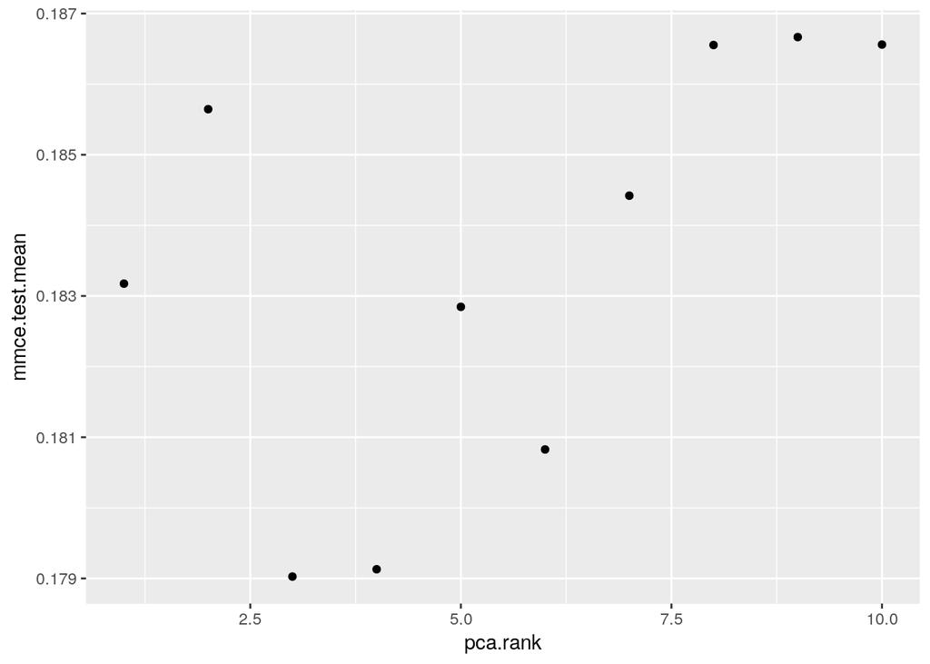

```r
effects = generateHyperParsEffectData(tuneres)
qplot(pca.rank, mmce.test.mean, data = effects$data)
```

(Note that all tuning result graphs shown were created using 10-fold repeated crossvalidation with 10 iterations, which reduces noise but takes a lot longer to run than the simple 10-fold crossvalidation used in the code.)

Making a comparison of `CPO` using three `PCA` components, using no `PCA`, or not using the added columns altogether, shows that the performance is similar, although not doing PCA has a slight edge.

```r
# using PCA
repcv(setHyperPars(tune.learner, pca.rank = 3),
  titanic.task)
```

```
## MMCE Mean 0.1776, SE 0.0008
```

```r
# the columns with no PCA
repcv(preproc.pipeline %>>% makeLearner("classif.randomForest"),
  titanic.task)
```

```
## MMCE Mean 0.1767, SE 0.0008
```

```r
# not using any columns used by the PCA
repcv(preproc.pipeline %>>% cpoSelect(pattern = "\\.topca$", invert = TRUE) %>>%
      makeLearner("classif.randomForest"),
  titanic.task)
```

```
## MMCE Mean 0.1810, SE 0.0006
```

### CPO Multiplexing and Tuning over Different Methods

Instead of just tuning over the number of PCA columns to include, we may also wonder whether using the similar ICA method is a better choice in this case. It would be useful to have a hyperparameter that controls which `CPO` gets applied: `cpoPca` or `cpoIca`. This is exactly what `cpoMultiplex` does: It is created with several candidate `CPO`s and exports a `selected.cpo` parameter. All hyperparameters of the included `CPO`s are exported as well, which makes it possible to not only tune over which `CPO` is used, but also over their parameters.

The following is a combination of the `cpoPca` and `cpoIca` `CPO`s. Looking at the resulting `CPO`’s parameter set shows that all the parameters of the included `CPO`s are exported.

```r
mplx = cpoMultiplex(list(cpoPca(scale = TRUE, export = "rank"),
  cpoIca(export = "n.comp")))

getParamIds(getParamSet(mplx))
```

```
## [1] "selected.cpo" "pca.rank"     "ica.n.comp"
```

We could tune this `CPO` as we do the one above, but it would be nicer if the different parameters controling number of components could be pulled together into a single parameter. This is done using `cpoTransformParams`, which wraps a `CPO`, creates new hyperparameters, and makes it possible to express the wrapped `CPO`’s hyperparameters in terms of the new hyperparameters.

```r
mplx.transformed = cpoTransformParams(mplx,
  transformations = alist(pca.rank = rank, ica.n.comp = rank),
  additional.parameters = makeParamSet(makeIntegerParam("rank", 1)))

getParamSet(mplx.transformed)
```

```
##                  Type len Def   Constr Req Tunable Trafo
## selected.cpo discrete   - pca  pca,ica   -    TRUE     -
## rank          integer   -   - 1 to Inf   -    TRUE     -
```

This newly created `CPO` can now be included in the preprocessing pipeline.

```r
general.ca = cpoModelMatrix(~0 + ., export = character(0)) %>>%
  cpoDropConstants(export = character(0)) %>>%
  cpoScale() %>>%
  mplx.transformed

ca.restricted = cpoCbind(
    cpoSelect(pattern = "\\.topca$", invert = TRUE, id = "restrict"),
    cpoSelect(pattern = "\\.topca$") %>>% general.ca)
```

Using different settings for `rank` and `selected.cpo` will now select the `CPO` to use, while independently setting the fraction of columns to return. To get the results of selecting one column of PCA as above, we use:

```r
head(getTaskData(titanic.task %>>% preproc.pipeline %>>%
                 setHyperPars(selected.cpo = "pca", ca.restricted, rank = 1)))
```

| Survived | Age | SibSp | Parch | Fare | Embarked | Title | missing.Age | missing.Embarked | PC1 |
| --- | --- | --- | --- | --- | --- | --- | --- | --- | --- |
| 0 | 22.00000 | 1 | 0 | 7.2500 | S | Mr. | FALSE | FALSE | 0.5921781 |
| 1 | 38.00000 | 1 | 0 | 71.2833 | C | Mrs. | FALSE | FALSE | -4.2228629 |
| 1 | 26.00000 | 0 | 0 | 7.9250 | S | Miss. | FALSE | FALSE | 1.5012187 |
| 1 | 35.00000 | 1 | 0 | 53.1000 | S | Mrs. | FALSE | FALSE | -2.7000424 |
| 0 | 35.00000 | 0 | 0 | 8.0500 | S | Mr. | FALSE | FALSE | 1.1370172 |
| 0 | 28.90861 | 0 | 0 | 8.4583 | Q | Mr. | TRUE | FALSE | 1.2717203 |

Using ICA gives a different result, but the same number of columns:

```r
head(getTaskData(titanic.task %>>% preproc.pipeline %>>%
                 setHyperPars(ca.restricted, selected.cpo = "ica", rank = 1)))
```

| Survived | Age | SibSp | Parch | Fare | Embarked | Title | missing.Age | missing.Embarked | V1 |
| --- | --- | --- | --- | --- | --- | --- | --- | --- | --- |
| 0 | 22.00000 | 1 | 0 | 7.2500 | S | Mr. | FALSE | FALSE | 0.3534827 |
| 1 | 38.00000 | 1 | 0 | 71.2833 | C | Mrs. | FALSE | FALSE | -2.4098077 |
| 1 | 26.00000 | 0 | 0 | 7.9250 | S | Miss. | FALSE | FALSE | 0.8474049 |
| 1 | 35.00000 | 1 | 0 | 53.1000 | S | Mrs. | FALSE | FALSE | -1.5449009 |
| 0 | 35.00000 | 0 | 0 | 8.0500 | S | Mr. | FALSE | FALSE | 0.6327985 |
| 0 | 28.53395 | 0 | 0 | 8.4583 | Q | Mr. | TRUE | FALSE | 0.7231275 |

We are now ready to tune this `CPO` instead of the one previously used. We re-define `tune.learner` and create a new tuning parameter set and are good to go.

```r
tune.learner = preproc.pipeline %>>%
  ca.restricted %>>%
  makeLearner("classif.randomForest")

ps = makeParamSet(
    makeDiscreteParam("selected.cpo", values = c("pca", "ica")),
    makeIntegerParam("rank", lower = 1, upper = 10))

tuneres = tuneParams(tune.learner, titanic.task, cv10, par.set = ps, control = ctrl)
tuneres
```

```
## Tune result:
## Op. pars: selected.cpo=pca; rank=4
## mmce.test.mean=0.1748801
```

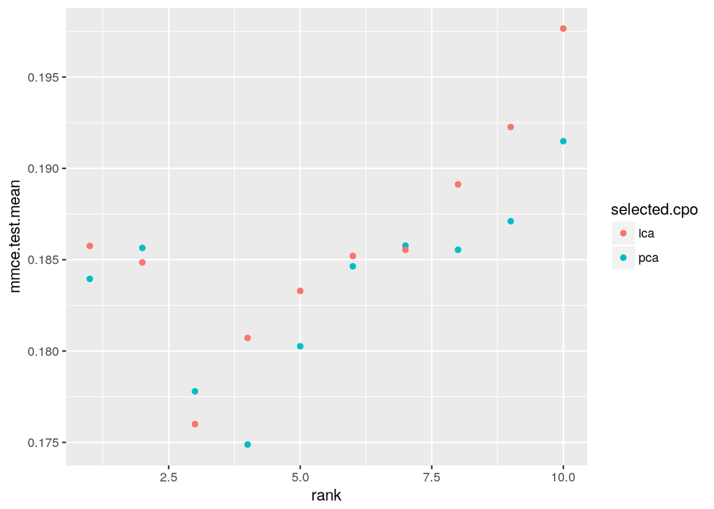

```r
effects = generateHyperParsEffectData(tuneres)
qplot(rank, mmce.test.mean, color = selected.cpo, data = effects$data)
```

The difference seems to be minute, but for most values PCA seems to outperform ICA.

```r
repcv(setHyperPars(tune.learner, rank = 3, selected.cpo = "ica"),
  titanic.task)
```

```
## MMCE Mean 0.1781, SE 0.0010
```

### Custom CPOs and Feature Clusters

Even though `mlrCPO` offers many versatile `CPO`s, it may happen that a method that is not present should be implemented. For this case, it is possible to create new `CPOConstructor`s using `makeCPO()`. To go deeper into the topic of creating custom CPOs, you can query the respective vignette using `vignette("a_4_custom_CPOs", package="mlrCPO")`, but the following gives a useful and relatively general example.

When looking at the distribution of the ticket numbers, we notice a few accumulation of points and might wonder whether having a ticket from one of these “clusters” gives any information about a passenger.

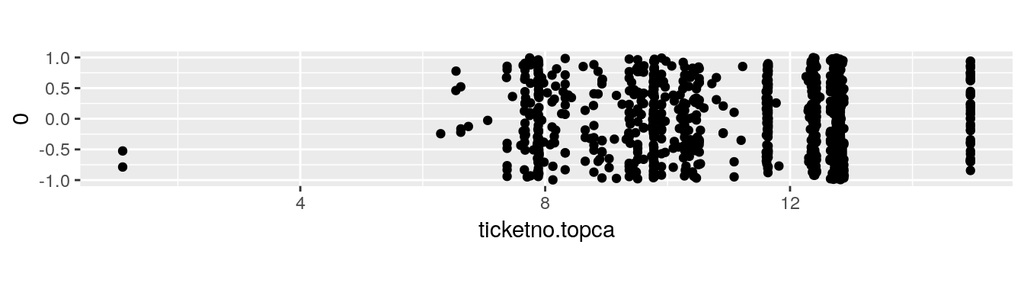

```r
ggplot(getTaskData(titanic.task %>>% preproc.pipeline),
  aes(ticketno.topca, 0)) + geom_jitter(height = 1) + coord_fixed()
```

We choose to use the `dbscan` library for clustering, even though there is no `CPO` available that implements it. The wrong approach would be to use `cpoAddCols` to add a column from the result of running `dbscan` on the input, because this would give different clusters during training and prediction. Instead, we need to implement a new `CPO` that assigns the correct clusters to new data values.

`makeCPO()` splits the preprocessing operation up into two functions: a `cpo.train` function that is applied only to the training data and returns a “control” object which contains all the trained information–in our case, the result from the `dbscan()` call–, and a `cpo.retrafo` function that is applied to both training and prediction data and does the actual data transformation–assigning the cluster index to every data point.

Our `CPO` will take only numeric values, and will return a single factorial column indicating cluster membership. We use the `properties.*` parameters of `makeCPO()` to indicate:

- that only numeric values are accepted (with missing values also accepted): `properties.data = c("numerics", "missings")`
- that if we attach the `CPO` to a `Learner`, it must be able to handle “factors”: `properties.needed = "factors"`
- that the `Learner` does not need to handle numeric values (since we are converting numerics to factors). Therefore, the “numerics” property is “added” to the `Learner` when the `CPO` gets attached: `properties.adding= "numerics"`

Our newly created `CPO` exports the “eps” parameter of `dbscan`, indicating the necessary proximity for cluster membership. This is declared by the `par.set` parameter of `makeCPO`.

```r
cpoDbscan = makeCPO(cpo.name = "dbscan",
  par.set = makeParamSet(makeNumericParam("eps", 0)),
  properties.data = c("numerics", "missings"),
  properties.needed = "factors",
  properties.adding = "numerics",
  packages = "dbscan",
  cpo.train = function(data, target, eps) {
    data = as.matrix(data)
    list(cluster = dbscan::dbscan(data, eps), data = data)
  },
  cpo.retrafo = function(data, control, eps) {
    prediction = predict(control$cluster, as.matrix(data), control$data)
    unique.clusters = sort(unique(control$cluster$cluster))
    result = data.frame(factor(prediction, levels = unique.clusters))
    names(result) = str_c(c("dbscan", colnames(data)), collapse = ".")
    result
  })
```

Inspecting the clustering done on both `titanic.table` and `test.table` shows that clustering work well:

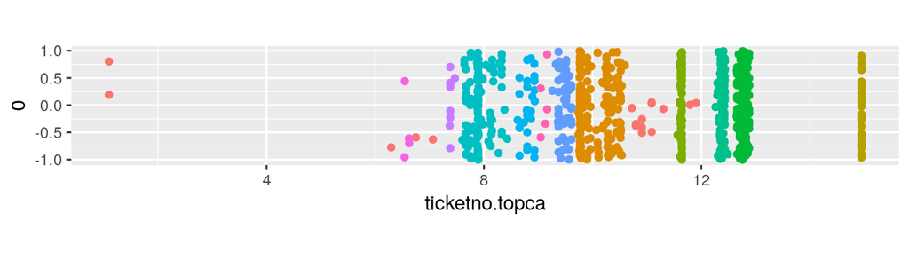

```r
clustered.train = titanic.task %>>% preproc.pipeline %>>%
  cpoSelectFreeProperties(names = "ticketno.topca") %>>%
  cpoCbind(NULLCPO, cpoDbscan(0.1))

ggplot(getTaskData(clustered.train, target.extra = TRUE)$data,
  aes(ticketno.topca, 0, color = dbscan.ticketno.topca)) +
  geom_jitter(height = 1, show.legend = FALSE) + coord_fixed()
```

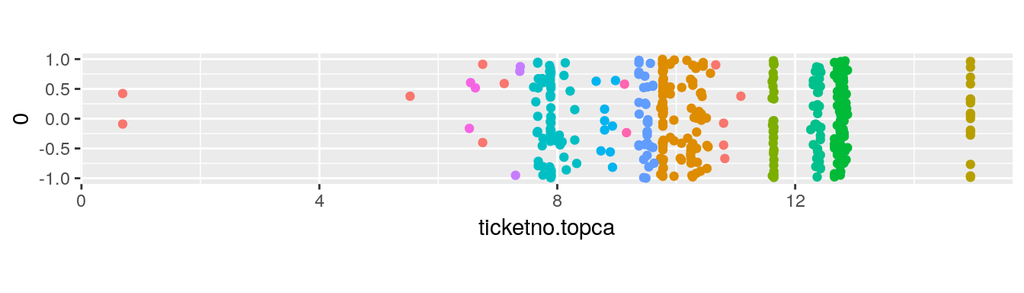

```r
clustered.predict = test.table %>>% retrafo(clustered.train)
ggplot(clustered.predict,
  aes(ticketno.topca, 0, color = dbscan.ticketno.topca)) +
  geom_jitter(height = 1, show.legend = FALSE) + coord_fixed()
```

We can use this to cluster ticket numbers (and drop the other `.topca` columns) and evaluate the resulting Learner.

```r
cluster.learner = preproc.pipeline %>>%
  cpoCbind(cpoSelect(pattern = "\\.topca$", invert = TRUE),
    cpoSelectFreeProperties(names = "ticketno.topca") %>>% cpoDbscan(0.1)) %>>%
  makeLearner("classif.randomForest")
```

```r
repcv(cluster.learner, titanic.task)
```

```
## MMCE Mean 0.1769, SE 0.0009
```